# 20220925：エリザベス女王の国葬

Takala

長きにわたりイギリス，コモンウェルスの君主であったエリザベス女王の国葬が先日行われた． メディアでは，女王は夫フィリップ殿下とともに埋葬されると述べられているが， 正直，火葬を伴わない埋葬について具体的イメージが湧かなかった．

調べてもあまり出て来ないのでよくわからないままだったが，Twitterで以下の画像を たまたま目にして少し謎が解けた．

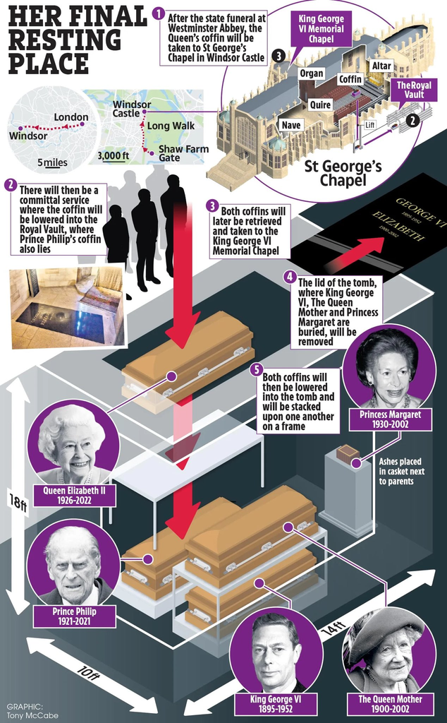

エリザベス2世の棺

この画像がすべて本当のことを言っているかどうかは分からないが，どうやら棺が地下室に並べられる，あるいは二段ベッド式に置かれるという ことになるようだ．土に埋めるわけではなかった． 確かに，ダ・ヴィンチ・コードでも，“埋葬”に関して，そのような記述だった気がする．

マーガレット王女が火葬だったのも興味深い． 火葬文化に生きているとどうしても，火葬しない文化に抵抗を覚えてしまう． 防腐処理までしていつまで保存するのかと考えてしまう．

やはり，諸行無常や輪廻転生の価値観が，東洋に比べると西洋はあまりないものなのかと思う． 不朽，永遠や復活の価値観が強いのかもしれない．